# lab_4

Merly Klaas

10/20/2021

## 1. Produce a subset of the data (as a new object) that has the following characteristics:

- only one team (your choice)
- (try to you select a team that is currently still around, or it probably won’t be interesting; see a list of current teams at http://www.espn.com/mlb/teams).
- data from 1980 to present (or as current as the dataset allows)
- includes 5 columns: name, yearID, W, L, R, RA. These 5 variables correspond to the team name, the year, wins, losses, runs scored, and runs allowed).

```r
dodgers <- Teams %>%
  filter(name == "Los Angeles Dodgers", yearID >= 1980) %>%
  select(name, yearID, W, L, R, RA) %>%
  as_tibble() %>%
  clean_names()
```

## 2. Create a new variable corresponding to the winning percentage for the team you chose over time:

```r
dodgers %>%
  mutate(wpct = w/(w+l)) %>%
  arrange(wpct) %>%
  mutate(mean_wpct = mean(wpct), sd_wpct = sd(wpct))
```

```
## # A tibble: 41 x 9
##    name                year_id     w     l     r    ra  wpct mean_wpct sd_wpct
##    <chr>                 <int> <int> <int> <int> <int> <dbl>     <dbl>   <dbl>
##  1 Los Angeles Dodgers    1992    63    99   548   636 0.389     0.540  0.0589
##  2 Los Angeles Dodgers    2005    71    91   685   755 0.438     0.540  0.0589
##  3 Los Angeles Dodgers    1986    73    89   638   679 0.451     0.540  0.0589
##  4 Los Angeles Dodgers    1987    73    89   635   675 0.451     0.540  0.0589
##  5 Los Angeles Dodgers    1999    77    85   793   787 0.475     0.540  0.0589
##  6 Los Angeles Dodgers    1989    77    83   554   536 0.481     0.540  0.0589
##  7 Los Angeles Dodgers    1984    79    83   580   600 0.488     0.540  0.0589
##  8 Los Angeles Dodgers    2010    80    82   667   692 0.494     0.540  0.0589
##  9 Los Angeles Dodgers    1993    81    81   675   662 0.5       0.540  0.0589
## 10 Los Angeles Dodgers    2007    82    80   735   727 0.506     0.540  0.0589
## # ... with 31 more rows
```

## 3. With the full Teams data:

- Compute the mean and standard deviation of winning percentage for each team and then

```r
Teams <-Teams %>%
  clean_names() %>%
  select(name, year_id, w, l, r, ra) %>%
  mutate(wpct = w/(w+l)) %>%
  arrange()


teams1 <- Teams %>%
  select(name, year_id, wpct, everything()) %>%
  group_by(name) %>%
  summarize(mean_wpct= mean (wpct, na.rm= TRUE), sd_wpct= sd(wpct,na.rm=TRUE))
teams1
```

```
## # A tibble: 139 x 3
##    name                  mean_wpct sd_wpct
##    <chr>                     <dbl>   <dbl>
##  1 Altoona Mountain City     0.24  NA
##  2 Anaheim Angels            0.512  0.0577
##  3 Arizona Diamondbacks      0.491  0.0762
##  4 Atlanta Braves            0.517  0.0806
##  5 Baltimore Canaries        0.482  0.253
##  6 Baltimore Marylands       0     NA
##  7 Baltimore Monumentals     0.552 NA
##  8 Baltimore Orioles         0.504  0.101
##  9 Baltimore Terrapins       0.425  0.170
## 10 Boston Americans          0.521  0.123
## # ... with 129 more rows
```

- Order by winning percentage, greatest to least

```r
#Teams %>%
#  arrange(wpct)
```

# 4. Use the full data to reproduce the plot below

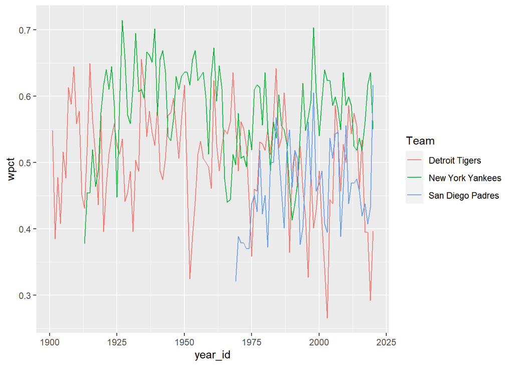

```r
Teams %>%
  filter (name=="Detroit Tigers"|
            name== "New York Yankees" |
            name == "San Diego Padres")  %>%
  arrange(desc(wpct)) %>%
  ggplot (aes(year_id, wpct, color = name))+
  geom_line() +
  labs (color= "Team")
```

## Plot 2

#Read in the following three datasets, using {here} and the package of your choice ({rio}, {readr}, {haven}, {readxl}) * sesame13.sav * star.csv * ais.xlsx Hint: For the ais.xlsx data, look at the skip argument within the {readxl} help documentation.

```r
sesame13 <- import(here ("data", "sesame13.sav"))
star <- read_csv(here("data","star.csv"))
ais <- read_excel(here("data", "ais.xlsx"), sheet = "ais.csv", skip =14)
```

2. Using the ais data, compute the average red blood cell count and average bmi by sport. Output these data as SPSS and EXCEL files.

```r
mean_rcc_bmi <- ais %>%
  group_by(sport) %>%
  summarize (mean_rcc = mean(rcc, na.rm=TRUE), mean_bmi = mean (bmi, na.rm= TRUE))
write_sav(mean_rcc_bmi, here("data", "mean_rcc_bmi.sav"))
write.csv(mean_rcc_bmi, here("data", "mean_rcc_bmi.csv"))
```

3. Use the sesame data to answer the following question: Was the average female age higher in schools or at home?

Answer: at school M=53.056

```r
sesame13 %>%
  characterize() %>%
  group_by(sex, setting) %>%
  summarize (mean= mean(age))
```

```
## # A tibble: 4 x 3
## # Groups:   sex [2]
##   sex    setting  mean
##   <chr>  <chr>   <dbl>
## 1 Female Home     49.4
## 2 Female School   53.1
## 3 Male   Home     50.9
## 4 Male   School   54.1
```

4. First, how many rows and columns are in the star data? Next, remove outliers using a really poor method, just for practice, by eliminating students whose math (tmathss) scores were more than three standard deviations above or below the corresponding mean. How many rows are in the data now?

```r
dim(star) #12 columns , 5748 rows
```

```
## [1] 5748   12
```

```r
m <- mean(star$tmathss)
sd<- sd(star$tmathss)
out.u <- m+(3*sd)
out.l <- m-(3*sd)
no.out <- filter(star, tmathss < out.u & tmathss > out.l) #Row in the data after taking out the outliers = 5743
dim (no.out)
```

```
## [1] 5743   12
```

5. Use the star data to compute standardized math and reading scores; name these variables tmathss and treadss. To create standardized scores, for each variable (math and reading), subtract the mean from each observation and divide by the standard deviation

```r
star1 <- star %>%
  mutate (tmathss = (tmathss-m)/sd, treadss = (treadss-mean(treadss))/sd(treadss))
```

Compute the mean of the standardized variable for all sex/frl combinations. (I’m asking you to extend what you know here. We haven’t talked explicitly about how to do this yet, but you have seen examples).

```r
star1 %>%
  summarize(mean_tmathss = mean(tmathss), mean_treadss = mean(treadss),
            sd_tmathsd = sd(tmathss), sd_treadsd = sd(treadss))
```

```
## # A tibble: 1 x 4
##   mean_tmathss mean_treadss sd_tmathsd sd_treadsd
##          <dbl>        <dbl>      <dbl>      <dbl>
## 1     2.30e-16    -6.28e-16          1          1
```

```r
star1 %>%
  group_by(sex, frl) %>%
  summarize(mean_tmathss = mean (tmathss), mean_treadss = mean(treadss),
            sd_tmathsd = sd(tmathss), sd_treadsd = sd(treadss))
```

```
## # A tibble: 4 x 6
## # Groups:   sex [2]
##   sex   frl   mean_tmathss mean_treadss sd_tmathsd sd_treadsd
##   <chr> <chr>        <dbl>        <dbl>      <dbl>      <dbl>
## 1 boy   no           0.151        0.148      0.970      1.02
## 2 boy   yes         -0.330       -0.358      0.965      0.838
## 3 girl  no           0.326        0.371      0.962      1.09
## 4 girl  yes         -0.170       -0.187      0.969      0.863
```

What do you make of these findings? Do you see an effect by sex? An frl effect (frl stands for free/reduced lunch, and is a rough proxy for household income)? Is there evidence of an interaction (i.e., that the effect of frl is greater for boys versus girls)?